# Project: Investigate a Dataset - [TMDb_movie_data]

- Introduction
- Data Wrangling
- Exploratory Data Analysis
- Conclusions

## Introduction

### Dataset Description

The dataset used in this project is the TMDb Movie Dataset, which contains information about thousands of movies collected from The Movie Database (TMDb). The dataset includes various attributes such as movie title, genres, popularity, budget, revenue, vote count, vote average, directors, cast members, and release dates.

These variables allow us to explore different aspects of movies such as financial performance, audience engagement, and popularity. The dataset provides useful information for analyzing movie success and identifying patterns between genres, directors, and profitability.

### Question(s) for Analysis

1. Which movie genre generates the highest average profit?
2. Who are the most successful directors?

```python
import numpy as np
import pandas as pd
import matplotlib.pyplot as plt
%matplotlib inline
```

## Data Wrangling

In this section, the dataset is loaded and inspected to understand its structure and identify potential data quality issues. After the initial exploration, the data is cleaned and prepared for analysis by handling missing values, removing invalid entries, correcting inconsistencies, and creating additional variables needed for the research questions.

### General Properties

To understand the overall structure of the dataset, several inspection methods are used, including viewing sample rows, checking data types, examining the dataset size, and identifying missing values. These steps help reveal the main characteristics of the data and guide the cleaning process.

The dataset was first loaded using pandas, and several inspection methods were applied to understand its structure and contents. Functions such as `head()`, `tail()`, `info()`, `shape`, `columns`, `dtypes`, `nunique()`, and `describe()` were used to explore the dataset size, data types, unique values, summary statistics, and possible data quality issues such as missing values and unusual values.

```python
df = pd.read_csv('Database_TMDb_movie_data/tmdb-movies.csv')
df.head(1)
```

|  | id | imdb_id | popularity | budget | revenue | original_title | cast | homepage | director | tagline | ... | overview | runtime | genres | production_companies | release_date | vote_count | vote_average | release_year | budget_adj | revenue_adj |
| --- | --- | --- | --- | --- | --- | --- | --- | --- | --- | --- | --- | --- | --- | --- | --- | --- | --- | --- | --- | --- | --- |
| 0 | 135397 | tt0369610 | 32.985763 | 150000000 | 1513528810 | Jurassic World | Chris Pratt\|Bryce Dallas Howard\|Irrfan Khan\|Vi... | http://www.jurassicworld.com/ | Colin Trevorrow | The park is open. | ... | Twenty-two years after the events of Jurassic ... | 124 | Action\|Adventure\|Science Fiction\|Thriller | Universal Studios\|Amblin Entertainment\|Legenda... | 6/9/15 | 5562 | 6.5 | 2015 | 1.379999e+08 | 1.392446e+09 |

1 rows × 21 columns

```python
df.info()
```

```
<class 'pandas.core.frame.DataFrame'>
RangeIndex: 10866 entries, 0 to 10865
Data columns (total 21 columns):
 #   Column                Non-Null Count  Dtype
---  ------                --------------  -----
 0   id                    10866 non-null  int64
 1   imdb_id               10856 non-null  object
 2   popularity            10866 non-null  float64
 3   budget                10866 non-null  int64
 4   revenue               10866 non-null  int64
 5   original_title        10866 non-null  object
 6   cast                  10790 non-null  object
 7   homepage              2936 non-null   object
 8   director              10822 non-null  object
 9   tagline               8042 non-null   object
 10  keywords              9373 non-null   object
 11  overview              10862 non-null  object
 12  runtime               10866 non-null  int64
 13  genres                10843 non-null  object
 14  production_companies  9836 non-null   object
 15  release_date          10866 non-null  object
 16  vote_count            10866 non-null  int64
 17  vote_average          10866 non-null  float64
 18  release_year          10866 non-null  int64
 19  budget_adj            10866 non-null  float64
 20  revenue_adj           10866 non-null  float64
dtypes: float64(4), int64(6), object(11)
memory usage: 1.7+ MB
```

```python
df.shape
```

```
(10866, 21)
```

```python
df.columns
```

```
Index(['id', 'imdb_id', 'popularity', 'budget', 'revenue', 'original_title',
       'cast', 'homepage', 'director', 'tagline', 'keywords', 'overview',
       'runtime', 'genres', 'production_companies', 'release_date',
       'vote_count', 'vote_average', 'release_year', 'budget_adj',
       'revenue_adj'],
      dtype='object')
```

```python
df.dtypes
```

```
id                        int64
imdb_id                  object
popularity              float64
budget                    int64
revenue                   int64
original_title           object
cast                     object
homepage                 object
director                 object
tagline                  object
keywords                 object
overview                 object
runtime                   int64
genres                   object
production_companies     object
release_date             object
vote_count                int64
vote_average            float64
release_year              int64
budget_adj              float64
revenue_adj             float64
dtype: object
```

```python
df.nunique()
```

```
id                      10865
imdb_id                 10855
popularity              10814
budget                    557
revenue                  4702
original_title          10571
cast                    10719
homepage                 2896
director                 5067
tagline                  7997
keywords                 8804
overview                10847
runtime                   247
genres                   2039
production_companies     7445
release_date             5909
vote_count               1289
vote_average               72
release_year               56
budget_adj               2614
revenue_adj              4840
dtype: int64
```

```python
df.describe()
```

|  | id | popularity | budget | revenue | runtime | vote_count | vote_average | release_year | budget_adj | revenue_adj |
| --- | --- | --- | --- | --- | --- | --- | --- | --- | --- | --- |
| count | 10866.000000 | 10866.000000 | 1.086600e+04 | 1.086600e+04 | 10866.000000 | 10866.000000 | 10866.000000 | 10866.000000 | 1.086600e+04 | 1.086600e+04 |
| mean | 66064.177434 | 0.646441 | 1.462570e+07 | 3.982332e+07 | 102.070863 | 217.389748 | 5.974922 | 2001.322658 | 1.755104e+07 | 5.136436e+07 |
| std | 92130.136561 | 1.000185 | 3.091321e+07 | 1.170035e+08 | 31.381405 | 575.619058 | 0.935142 | 12.812941 | 3.430616e+07 | 1.446325e+08 |
| min | 5.000000 | 0.000065 | 0.000000e+00 | 0.000000e+00 | 0.000000 | 10.000000 | 1.500000 | 1960.000000 | 0.000000e+00 | 0.000000e+00 |
| 25% | 10596.250000 | 0.207583 | 0.000000e+00 | 0.000000e+00 | 90.000000 | 17.000000 | 5.400000 | 1995.000000 | 0.000000e+00 | 0.000000e+00 |
| 50% | 20669.000000 | 0.383856 | 0.000000e+00 | 0.000000e+00 | 99.000000 | 38.000000 | 6.000000 | 2006.000000 | 0.000000e+00 | 0.000000e+00 |
| 75% | 75610.000000 | 0.713817 | 1.500000e+07 | 2.400000e+07 | 111.000000 | 145.750000 | 6.600000 | 2011.000000 | 2.085325e+07 | 3.369710e+07 |
| max | 417859.000000 | 32.985763 | 4.250000e+08 | 2.781506e+09 | 900.000000 | 9767.000000 | 9.200000 | 2015.000000 | 4.250000e+08 | 2.827124e+09 |

```python
df.tail(1)
```

|  | id | imdb_id | popularity | budget | revenue | original_title | cast | homepage | director | tagline | ... | overview | runtime | genres | production_companies | release_date | vote_count | vote_average | release_year | budget_adj | revenue_adj |
| --- | --- | --- | --- | --- | --- | --- | --- | --- | --- | --- | --- | --- | --- | --- | --- | --- | --- | --- | --- | --- | --- |
| 10865 | 22293 | tt0060666 | 0.035919 | 19000 | 0 | Manos: The Hands of Fate | Harold P. Warren\|Tom Neyman\|John Reynolds\|Dian... | NaN | Harold P. Warren | It's Shocking! It's Beyond Your Imagination! | ... | A family gets lost on the road and stumbles up... | 74 | Horror | Norm-Iris | 11/15/66 | 15 | 1.5 | 1966 | 127642.279154 | 0.0 |

1 rows × 21 columns

### here I have explored my dataset , columns and data types , also I looked for missing data and outliers

### Data Cleaning

In this part, the dataset is cleaned step by step to make it more suitable for analysis. Missing values, duplicate rows, inconsistent date values, and invalid financial entries are handled carefully. Each cleaning decision is explained to show how the dataset was prepared for answering the research questions.

After the initial inspection, missing values were examined using `isna().sum()`. This step helped identify which columns contained null values and how many missing entries existed in each column. The inspection showed that some columns, such as `homepage`, `tagline`, `keywords`, `cast`, `director`, and `production_companies`, had a noticeable number of missing values.

```python
df.isna().sum()
```

```
id                         0
imdb_id                   10
popularity                 0
budget                     0
revenue                    0
original_title             0
cast                      76
homepage                7930
director                  44
tagline                 2824
keywords                1493
overview                   4
runtime                    0
genres                    23
production_companies    1030
release_date               0
vote_count                 0
vote_average               0
release_year               0
budget_adj                 0
revenue_adj                0
dtype: int64
```

```python
df[df['imdb_id'].isna()]
```

|  | id | imdb_id | popularity | budget | revenue | original_title | cast | homepage | director | tagline | ... | overview | runtime | genres | production_companies | release_date | vote_count | vote_average | release_year | budget_adj | revenue_adj |
| --- | --- | --- | --- | --- | --- | --- | --- | --- | --- | --- | --- | --- | --- | --- | --- | --- | --- | --- | --- | --- | --- |
| 548 | 355131 | NaN | 0.108072 | 0 | 0 | Sense8: Creating the World | Tuppence Middleton\|Bae Doona \|Brian J. Smith\|A... | NaN | NaN | NaN | ... | NaN | 25 | Documentary\|Science Fiction | Netflix | 8/10/15 | 12 | 7.5 | 2015 | 0.000000 | 0.0 |
| 997 | 287663 | NaN | 0.330431 | 0 | 0 | Star Wars Rebels: Spark of Rebellion | Freddie Prinze Jr.\|Vanessa Marshall\|Steve Blum... | NaN | Steward Lee\|Steven G. Lee | NaN | ... | A Long Time Ago In A Galaxy Far, Far Away… A... | 44 | NaN | NaN | 10/3/14 | 13 | 6.8 | 2014 | 0.000000 | 0.0 |
| 1528 | 15257 | NaN | 0.607851 | 0 | 0 | Hulk vs. Wolverine | Fred Tatasciore\|Bryce Johnson\|Steve Blum\|Nolan... | NaN | Frank Paur | NaN | ... | Department H sends in Wolverine to track down ... | 38 | Animation\|Action\|Science Fiction | Marvel Studios | 1/27/09 | 38 | 6.9 | 2009 | 0.000000 | 0.0 |
| 1750 | 101907 | NaN | 0.256975 | 0 | 0 | Hulk vs. Thor | Graham McTavish\|Fred Tatasciore\|Matthew Wolf\|J... | NaN | Sam Liu | A Battle Between God and Monster | ... | For ages, Odin has protected his kingdom of As... | 41 | Action\|Animation\|Fantasy\|Science Fiction | Marvel Studios | 1/27/09 | 38 | 6.4 | 2009 | 0.000000 | 0.0 |
| 2401 | 45644 | NaN | 0.067753 | 0 | 0 | Opeth: In Live Concert At The Royal Albert Hall | Mikael Åkerfeldt\|Martin "Axe" Axenrot\|Martin ... | http://www.opeth.com | NaN | The Loyal Disharmonic Orchestra, Conducted By ... | ... | As part of the ongoing celebration of their 20... | 163 | Music | NaN | 9/21/10 | 10 | 8.6 | 2010 | 0.000000 | 0.0 |
| 4797 | 369145 | NaN | 0.167501 | 0 | 0 | Doctor Who: The Snowmen | Matt Smith\|Jenna Coleman\|Richard E. Grant\|Ian ... | NaN | NaN | NaN | ... | Christmas Eve, 1892, and the falling snow is t... | 60 | NaN | BBC Television UK | 12/25/12 | 10 | 7.8 | 2012 | 0.000000 | 0.0 |
| 4872 | 269177 | NaN | 0.090552 | 0 | 0 | Party Bercy | Florence Foresti | NaN | NaN | NaN | ... | Florence Foresti is offered Bercy tribute to a... | 120 | Comedy | TF1 Vidéo | 9/23/12 | 15 | 6.4 | 2012 | 0.000000 | 0.0 |
| 6071 | 279954 | NaN | 0.004323 | 500 | 0 | Portal: Survive! | Monique Blanchard\|Bradley Mixon | https://www.kickstarter.com/projects/colinandc... | Connor McGuire\|Colin McGuire | The Cake is a Lie | ... | A short, live action fan film by Collin and Co... | 7 | Action\|Science Fiction | NaN | 10/8/13 | 11 | 7.5 | 2013 | 468.016676 | 0.0 |
| 7527 | 50127 | NaN | 0.570337 | 0 | 0 | Fallen: The Journey | Paul Wesley\|Fernanda Andrade\|Tom Skerritt\|Rick... | NaN | Mikael Salomon | NaN | ... | A year later, Aaron is still traveling around ... | 80 | Action\|Adventure\|Drama\|Fantasy\|Family | NaN | 1/1/07 | 11 | 7.3 | 2007 | 0.000000 | 0.0 |
| 7809 | 50128 | NaN | 0.060795 | 0 | 0 | Fallen: The Destiny | Paul Wesley\|Fernanda Andrade\|Tom Skerritt\|Rick... | NaN | Mikael Salomon | NaN | ... | Aaron and Azazel defeat the Powers, and force ... | 80 | Adventure\|Fantasy\|Drama\|Action\|Science Fiction | NaN | 1/1/07 | 13 | 7.0 | 2007 | 0.000000 | 0.0 |

10 rows × 21 columns

Rows with missing `imdb_id` values were removed because this column is an important identifier for movies, and missing values in such a key field reduce data quality and consistency.

```python
df = df.dropna(subset=['imdb_id'])
```

```python
df[df['cast'].isna()]
```

|  | id | imdb_id | popularity | budget | revenue | original_title | cast | homepage | director | tagline | ... | overview | runtime | genres | production_companies | release_date | vote_count | vote_average | release_year | budget_adj | revenue_adj |
| --- | --- | --- | --- | --- | --- | --- | --- | --- | --- | --- | --- | --- | --- | --- | --- | --- | --- | --- | --- | --- | --- |
| 371 | 345637 | tt4661600 | 0.422901 | 0 | 0 | Sanjay's Super Team | NaN | NaN | Sanjay Patel | NaN | ... | Sanjay's Super Team follows the daydream of a ... | 7 | Animation | Pixar Animation Studios | 11/25/15 | 47 | 6.9 | 2015 | 0.000000 | 0.0 |
| 441 | 355020 | tt4908644 | 0.220751 | 0 | 0 | Winter on Fire: Ukraine's Fight for Freedom | NaN | http://www.netflix.com/title/80031666 | Evgeny Afineevsky | The Next Generation Of Revolution | ... | A documentary on the unrest in Ukraine during ... | 98 | Documentary | Passion Pictures\|Campbell Grobman Films\|Afinee... | 10/9/15 | 37 | 8.2 | 2015 | 0.000000 | 0.0 |
| 465 | 321109 | tt4393514 | 0.201696 | 0 | 0 | Bitter Lake | NaN | NaN | Adam Curtis | NaN | ... | An experimental documentary that explores Saud... | 135 | Documentary | BBC | 1/24/15 | 19 | 7.8 | 2015 | 0.000000 | 0.0 |
| 536 | 333350 | tt3762974 | 0.122543 | 0 | 0 | A Faster Horse | NaN | NaN | David Gelb | NaN | ... | David Gelb (Jiro Dreams of Sushi) tackles anot... | 90 | Documentary | NaN | 10/8/15 | 12 | 8.0 | 2015 | 0.000000 | 0.0 |
| 538 | 224972 | tt3983674 | 0.114264 | 0 | 0 | The Mask You Live In | NaN | http://themaskyoulivein.org | Jennifer Siebel Newsom | Is american masculinity harming our boys, men ... | ... | Compared to girls, research shows that boys in... | 88 | Documentary | NaN | 1/1/15 | 11 | 8.9 | 2015 | 0.000000 | 0.0 |
| ... | ... | ... | ... | ... | ... | ... | ... | ... | ... | ... | ... | ... | ... | ... | ... | ... | ... | ... | ... | ... | ... |
| 9677 | 13926 | tt0093832 | 0.253376 | 0 | 0 | Red's Dream | NaN | NaN | John Lasseter | NaN | ... | Life as the sole sale item in the clearance co... | 4 | Animation | Pixar Animation Studios | 8/17/87 | 44 | 6.6 | 1987 | 0.000000 | 0.0 |
| 9755 | 48714 | tt0061402 | 0.046272 | 0 | 0 | The Big Shave | NaN | NaN | Martin Scorsese | NaN | ... | This short film is a metaphor for the Vietnam ... | 6 | Drama | NaN | 1/1/68 | 12 | 6.7 | 1968 | 0.000000 | 0.0 |
| 10434 | 48784 | tt0060984 | 0.146906 | 200 | 0 | Six Men Getting Sick | NaN | NaN | David Lynch | NaN | ... | Lynch's first film project consists of a loop ... | 4 | Animation | Pensylvania Academy of Fine Arts | 1/1/67 | 16 | 5.2 | 1967 | 1307.352748 | 0.0 |
| 10550 | 13925 | tt0091455 | 0.306425 | 0 | 0 | Luxo Jr. | NaN | http://www.pixar.com/short_films/Theatrical-Sh... | John Lasseter | NaN | ... | A baby lamp finds a ball to play with and it's... | 2 | Animation\|Family | Pixar Animation Studios | 8/17/86 | 81 | 7.3 | 1986 | 0.000000 | 0.0 |
| 10754 | 3171 | tt0064064 | 0.002757 | 0 | 0 | Bambi Meets Godzilla | NaN | NaN | Marv Newland | NaN | ... | Bambi is nibbling the grass, unaware of the up... | 2 | Animation\|Comedy | NaN | 1/1/69 | 12 | 5.6 | 1969 | 0.000000 | 0.0 |

76 rows × 21 columns

Missing values in the `cast` column were replaced with `"Unknown"` instead of dropping the rows. This was done to preserve the movie records while clearly indicating that cast information was unavailable.

```python
df['cast'].fillna('Unknown' , inplace = True)
```

The `homepage` column was dropped because it contained a very large number of missing values and was not important for the analysis questions. Removing this column simplified the dataset without affecting the main analysis.

```python
df.drop('homepage' , axis=1 , inplace=True)
```

Rows with missing `director` values were removed because the director variable was important for one of the main analysis questions. Keeping rows without director information would make the director analysis incomplete and less reliable.

```python
df = df.dropna(subset=['director'])
```

Missing values in the `tagline` column were filled with `"Unavailable"` because this column was not central to the main analysis, and replacing null values helped keep the dataset clean and complete.

```python
df['tagline'].fillna('Unavailble' , inplace = True)
```

Rows with missing `keywords` values were removed because the keywords field was useful for descriptive information about movies, and keeping missing entries would reduce the consistency of the cleaned dataset.

```python
df = df.dropna(subset=['keywords'])
```

Rows with missing `overview` values were dropped because the overview provides descriptive context about each movie, and the number of missing values in this column was very small.

```python
df = df.dropna(subset=['overview'])
```

Rows with missing `genres` values were removed because genre information was essential for the main research question about movie profitability by genre. Without genre values, those rows could not be used in the analysis.

```python
df = df.dropna(subset=['genres'])
```

Missing values in the `production_companies` column were replaced with `"Unknown"` instead of deleting the rows. This allowed the records to remain in the dataset while still indicating that the production company information was unavailable.

```python
df['production_companies'].fillna('Unknown' , inplace = True)
```

The `release_date` column was converted to a datetime format using `pd.to_datetime()` so that it could be handled properly as a date variable in later analysis and cleaning steps.

```python
df['release_date'] = pd.to_datetime(df['release_date'])
```

The dataset was checked for duplicate rows using `duplicated().sum()`. One duplicate row was found and removed to avoid repeated observations affecting the analysis results.

```python
df.duplicated().sum()
```

```
1
```

```python
df[df.duplicated()]
```

|  | id | imdb_id | popularity | budget | revenue | original_title | cast | director | tagline | keywords | overview | runtime | genres | production_companies | release_date | vote_count | vote_average | release_year | budget_adj | revenue_adj |
| --- | --- | --- | --- | --- | --- | --- | --- | --- | --- | --- | --- | --- | --- | --- | --- | --- | --- | --- | --- | --- |
| 2090 | 42194 | tt0411951 | 0.59643 | 30000000 | 967000 | TEKKEN | Jon Foo\|Kelly Overton\|Cary-Hiroyuki Tagawa\|Ian... | Dwight H. Little | Survival is no game | martial arts\|dystopia\|based on video game\|mart... | In the year of 2039, after World Wars destroy ... | 92 | Crime\|Drama\|Action\|Thriller\|Science Fiction | Namco\|Light Song Films | 2010-03-20 | 110 | 5.0 | 2010 | 30000000.0 | 967000.0 |

```python
df.drop_duplicates(inplace=True)
```

```python
df.duplicated().sum()
```

```
0
```

Rows with zero values in `budget` and `revenue` were removed because, in this dataset, zero values most likely represent missing or unavailable financial data rather than true values. Since profit calculation depends on both budget and revenue, keeping such rows would produce misleading profit results.

```python
df[df['budget'] == 0]
```

|  | id | imdb_id | popularity | budget | revenue | original_title | cast | director | tagline | keywords | overview | runtime | genres | production_companies | release_date | vote_count | vote_average | release_year | budget_adj | revenue_adj |
| --- | --- | --- | --- | --- | --- | --- | --- | --- | --- | --- | --- | --- | --- | --- | --- | --- | --- | --- | --- | --- |
| 30 | 280996 | tt3168230 | 3.927333 | 0 | 29355203 | Mr. Holmes | Ian McKellen\|Milo Parker\|Laura Linney\|Hattie M... | Bill Condon | The man behind the myth | london\|detective\|sherlock holmes | The story is set in 1947, following a long-ret... | 103 | Mystery\|Drama | BBC Films\|See-Saw Films\|FilmNation Entertainme... | 2015-06-19 | 425 | 6.4 | 2015 | 0.0 | 2.700677e+07 |
| 36 | 339527 | tt1291570 | 3.358321 | 0 | 22354572 | Solace | Abbie Cornish\|Jeffrey Dean Morgan\|Colin Farrel... | Afonso Poyart | A serial killer who can see your future, a psy... | thriller\|serial killer\|psychic\|fbi agent\|intrigue | A psychic doctor, John Clancy, works with an F... | 101 | Crime\|Drama\|Mystery | Eden Rock Media\|FilmNation Entertainment\|Flynn... | 2015-09-03 | 474 | 6.2 | 2015 | 0.0 | 2.056620e+07 |
| 72 | 284289 | tt2911668 | 2.272044 | 0 | 45895 | Beyond the Reach | Michael Douglas\|Jeremy Irvine\|Hanna Mangan Law... | Jean-Baptiste Léonetti | Unavailble | desert\|hunting | A high-rolling corporate shark and his impover... | 95 | Thriller | Furthur Films | 2015-04-17 | 81 | 5.5 | 2015 | 0.0 | 4.222338e+04 |
| 74 | 347096 | tt3478232 | 2.165433 | 0 | 0 | Mythica: The Darkspore | Melanie Stone\|Kevin Sorbo\|Adam Johnson\|Jake St... | Anne K. Black | Unavailble | sword\|magic\|sorcery\|necromancer\|woman director | When Teela’s sister is murdered and a powerf... | 108 | Action\|Adventure\|Fantasy | Arrowstorm Entertainment | 2015-06-24 | 27 | 5.1 | 2015 | 0.0 | 0.000000e+00 |
| 75 | 308369 | tt2582496 | 2.141506 | 0 | 0 | Me and Earl and the Dying Girl | Thomas Mann\|RJ Cyler\|Olivia Cooke\|Connie Britt... | Alfonso Gomez-Rejon | A Little Friendship Never Killed Anyone. | tattoo\|high school\|leukemia\|friends\|parody | Greg is coasting through senior year of high s... | 105 | Comedy\|Drama | Indian Paintbrush | 2015-06-12 | 569 | 7.7 | 2015 | 0.0 | 0.000000e+00 |
| ... | ... | ... | ... | ... | ... | ... | ... | ... | ... | ... | ... | ... | ... | ... | ... | ... | ... | ... | ... | ... |
| 10860 | 5060 | tt0060214 | 0.087034 | 0 | 0 | Carry On Screaming! | Kenneth Williams\|Jim Dale\|Harry H. Corbett\|Joa... | Gerald Thomas | Carry On Screaming with the Hilarious CARRY ON... | monster\|carry on\|horror spoof | The sinister Dr Watt has an evil scheme going.... | 87 | Comedy | Peter Rogers Productions\|Anglo-Amalgamated Fil... | 2066-05-20 | 13 | 7.0 | 1966 | 0.0 | 0.000000e+00 |
| 10861 | 21 | tt0060371 | 0.080598 | 0 | 0 | The Endless Summer | Michael Hynson\|Robert August\|Lord 'Tally Ho' B... | Bruce Brown | Unavailble | surfer\|surfboard\|surfing | The Endless Summer, by Bruce Brown, is one of ... | 95 | Documentary | Bruce Brown Films | 2066-06-15 | 11 | 7.4 | 1966 | 0.0 | 0.000000e+00 |
| 10862 | 20379 | tt0060472 | 0.065543 | 0 | 0 | Grand Prix | James Garner\|Eva Marie Saint\|Yves Montand\|Tosh... | John Frankenheimer | Cinerama sweeps YOU into a drama of speed and ... | car race\|racing\|formula 1 | Grand Prix driver Pete Aron is fired by his te... | 176 | Action\|Adventure\|Drama | Cherokee Productions\|Joel Productions\|Douglas ... | 2066-12-21 | 20 | 5.7 | 1966 | 0.0 | 0.000000e+00 |
| 10863 | 39768 | tt0060161 | 0.065141 | 0 | 0 | Beregis Avtomobilya | Innokentiy Smoktunovskiy\|Oleg Efremov\|Georgi Z... | Eldar Ryazanov | Unavailble | car\|trolley\|stealing car | An insurance agent who moonlights as a carthie... | 94 | Mystery\|Comedy | Mosfilm | 2066-01-01 | 11 | 6.5 | 1966 | 0.0 | 0.000000e+00 |
| 10864 | 21449 | tt0061177 | 0.064317 | 0 | 0 | What's Up, Tiger Lily? | Tatsuya Mihashi\|Akiko Wakabayashi\|Mie Hama\|Joh... | Woody Allen | WOODY ALLEN STRIKES BACK! | spoof | In comic Woody Allen's film debut, he took the... | 80 | Action\|Comedy | Benedict Pictures Corp. | 2066-11-02 | 22 | 5.4 | 1966 | 0.0 | 0.000000e+00 |

4513 rows × 20 columns

```python
df = df[df['budget'] != 0]
```

```python
df = df[df['revenue'] != 0]
```

After converting the release date column, some dates appeared inconsistent with the `release_year` column. For example, a movie with `release_year = 1966` appeared with a `release_date` in 2066. To correct this issue, the month and day were preserved from `release_date`, while the year was rebuilt using the correct `release_year` value.

```python
df['month_day'] = df['release_date'].dt.strftime('%m-%d')
```

```python
df['release_date'] = pd.to_datetime(df['release_year'].astype(str) + '-' + df['month_day'])
```

A new column called `profit` was created to measure movie profitability. It was calculated as:

`profit = revenue_adj - budget_adj`

The adjusted revenue and adjusted budget columns were used instead of the original values to account for inflation and make comparisons across different years more fair.

```python
df['profit'] = df['revenue_adj'] - df['budget_adj']
```

It was observed that some columns, such as `genres` and `director`, contained multiple values in a single cell separated by `"|"`. This meant that those columns needed to be split and expanded later so that each value could be analyzed separately.

```python
# Reusable function to split multi-value columns and expand them into separate rows
def split_and_explode(dataframe, column):
    df_copy = dataframe.copy()
    df_copy[column] = df_copy[column].str.split('|')
    df_copy = df_copy.explode(column)
    return df_copy
```

```python
df_genres = split_and_explode(df, 'genres')
```

```python
df_director = split_and_explode(df, 'director')
```

## Exploratory Data Analysis

In this section, the cleaned dataset is explored in order to answer the research questions stated in the introduction. Summary statistics and visualizations are used to identify patterns, compare variables, and draw conclusions about movie genres, profitability, and directors.

The analysis is carried out systematically by first examining single variables and then exploring relationships between multiple variables. Different statistical summaries and visualizations are used to better understand trends in the data and support the findings.

### Research Question 1 (Which Genre gets more Profit!)

```python
# Use this, and more code cells, to explore your data. Don't forget to add
#   Markdown cells to document your observations and findings.
df_genres.groupby('genres')['profit'].mean()
```

```
genres
Action             1.327129e+08
Adventure          1.942274e+08
Animation          2.121388e+08
Comedy             8.480733e+07
Crime              7.256016e+07
Documentary        1.913468e+07
Drama              6.914516e+07
Family             1.792805e+08
Fantasy            1.728600e+08
Foreign            3.001138e+06
History            6.611343e+07
Horror             5.937011e+07
Music              1.019875e+08
Mystery            7.229787e+07
Romance            8.321619e+07
Science Fiction    1.385426e+08
TV Movie           5.143802e+07
Thriller           8.553019e+07
War                1.013035e+08
Western            6.982232e+07
Name: profit, dtype: float64
```

To answer the first research question, the dataset was grouped by genre and the average profit was calculated for each genre. The results show that Animation has the highest average profit among all movie genres, followed by Adventure, Family, and Fantasy.

```python
df_genres.groupby('genres')['vote_average'].mean()
```

```
genres
Action             6.054381
Adventure          6.140741
Animation          6.404592
Comedy             6.042198
Crime              6.317329
Documentary        6.717647
Drama              6.410130
Family             6.153186
Fantasy            6.072280
Foreign            6.490000
History            6.579365
Horror             5.723490
Music              6.335385
Mystery            6.196154
Romance            6.201575
Science Fiction    6.027593
TV Movie           5.600000
Thriller           6.077597
War                6.585345
Western            6.472549
Name: vote_average, dtype: float64
```

To better understand whether highly profitable genres are also highly rated, the average vote rating was calculated for each genre. The results indicate that Documentary has the highest average rating, while Animation also has a relatively high average rating compared to many other genres.

```python
df_genres.groupby('genres')[['popularity' , 'vote_average'  ,'profit'  , 'budget_adj']].mean().sort_values('budget_adj' , ascending=False)
```

| genres | popularity | vote_average | profit | budget_adj |
| --- | --- | --- | --- | --- |
| Animation | 1.745303 | 6.404592 | 2.121388e+08 | 8.420087e+07 |
| Adventure | 1.898399 | 6.140741 | 1.942274e+08 | 8.213960e+07 |
| Fantasy | 1.775482 | 6.072280 | 1.728600e+08 | 8.086470e+07 |
| Family | 1.503973 | 6.153186 | 1.792805e+08 | 7.245010e+07 |
| Western | 1.143814 | 6.472549 | 6.982232e+07 | 6.811137e+07 |
| Action | 1.599768 | 6.054381 | 1.327129e+08 | 6.749638e+07 |
| Science Fiction | 1.890452 | 6.027593 | 1.385426e+08 | 6.629715e+07 |
| War | 1.261136 | 6.585345 | 1.013035e+08 | 5.844194e+07 |
| History | 0.976946 | 6.579365 | 6.611343e+07 | 5.789656e+07 |
| Thriller | 1.276801 | 6.077597 | 8.553019e+07 | 4.504327e+07 |
| Mystery | 1.147582 | 6.196154 | 7.229787e+07 | 4.224247e+07 |
| Crime | 1.138734 | 6.317329 | 7.256016e+07 | 4.043391e+07 |
| Comedy | 1.037183 | 6.042198 | 8.480733e+07 | 3.987218e+07 |
| Music | 0.912787 | 6.335385 | 1.019875e+08 | 3.562775e+07 |
| Drama | 1.021701 | 6.410130 | 6.914516e+07 | 3.529753e+07 |
| Romance | 0.977252 | 6.201575 | 8.321619e+07 | 3.461281e+07 |
| Horror | 0.866079 | 5.723490 | 5.937011e+07 | 2.350025e+07 |
| Foreign | 0.182215 | 6.490000 | 3.001138e+06 | 1.157069e+07 |
| TV Movie | 0.273628 | 5.600000 | 5.143802e+07 | 6.951084e+06 |
| Documentary | 0.300911 | 6.717647 | 1.913468e+07 | 5.468094e+06 |

A comparison of multiple variables by genre was then performed, including popularity, vote average, profit, and adjusted budget. The results show that Animation not only has the highest average profit, but it also has one of the highest adjusted budgets and strong popularity values. This suggests that Animation movies tend to receive large investments and also generate strong returns.

```python
animation_df = df[df['genres'].str.contains('Animation')]
```

Since Animation appeared to be the most profitable genre, a separate subset of Animation movies was created to explore this genre in more detail and better understand the factors behind its strong financial performance.

```python
animation_df[['profit' , 'original_title']].sort_values('profit' , ascending=False)
```

|  | profit | original_title |
| --- | --- | --- |
| 10110 | 1.545635e+09 | One Hundred and One Dalmatians |
| 10398 | 1.319404e+09 | The Jungle Book |
| 4180 | 1.093392e+09 | The Lion King |
| 5422 | 1.052306e+09 | Frozen |
| 8 | 9.961120e+08 | Minions |
| ... | ... | ... |
| 2747 | -7.561717e+07 | Osmosis Jones |
| 2802 | -8.569985e+07 | Monkeybone |
| 6590 | -9.144505e+07 | Flushed Away |
| 3484 | -1.076102e+08 | Mars Needs Moms |
| 4970 | -1.185350e+08 | Brother Bear |

196 rows × 2 columns

The most and least profitable Animation movies were examined. The results show that several classic and highly successful Animation films, such as *One Hundred and One Dalmatians*, *The Jungle Book*, *The Lion King*, and *Frozen*, generated extremely high profits. On the other hand, some Animation movies produced financial losses, indicating that not all movies in this genre are equally successful.

```python
animation_df[['revenue_adj' ,'budget_adj']].mean()
```

```
revenue_adj    2.963396e+08
budget_adj     8.420087e+07
dtype: float64
```

The average adjusted revenue and adjusted budget of Animation movies were calculated. The results show that Animation movies have a high average budget, but their average revenue is much higher, which explains why this genre achieves the highest average profit overall.

```python
animation_df[['original_title' , 'budget_adj']].sort_values('budget_adj' , ascending=False)
```

|  | original_title | budget_adj |
| --- | --- | --- |
| 1929 | Tangled | 2.600000e+08 |
| 1416 | A Christmas Carol | 2.032801e+08 |
| 1930 | Toy Story 3 | 2.000000e+08 |
| 3393 | Cars 2 | 1.938796e+08 |
| 6976 | The Polar Express | 1.904835e+08 |
| ... | ... | ... |
| 10793 | Watership Down | 3.342701e+06 |
| 819 | Justice League: War | 3.223819e+06 |
| 8046 | Fire and Ice | 2.627174e+06 |
| 3014 | Vals Im Bashir | 2.025573e+06 |
| 2191 | Halo Legends | 1.000000e+05 |

196 rows × 2 columns

The Animation movies with the highest adjusted budgets were also examined. This analysis shows that many Animation movies require large production budgets, which is expected due to the intensive production process. However, despite these high costs, Animation films still tend to generate very strong revenues.

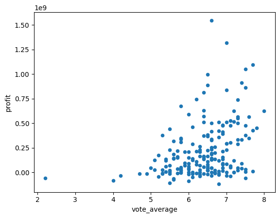

```python
animation_df.plot.scatter(x='vote_average' , y='profit')
```

A scatter plot was created to explore the relationship between vote average and profit within Animation movies. The plot suggests that there is no very strong direct relationship between rating and profit, meaning that highly rated Animation movies are not always the most profitable ones.

```python
pd.plotting.scatter_matrix(animation_df , figsize=(15,15))
```

[output not shown]

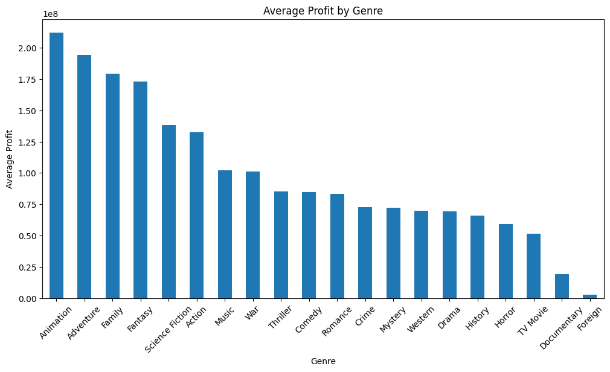

```python
df_genres.groupby('genres')['profit'].mean().sort_values(ascending=False).plot(
    kind='bar',
    figsize=(12,6)
)

plt.title('Average Profit by Genre')
plt.xlabel('Genre')
plt.ylabel('Average Profit')
plt.xticks(rotation=45)
plt.show()
```

A bar chart was created to compare the average profit across movie genres. The chart clearly shows that Animation has the highest average profit, followed by Adventure and Family. This visualization makes it easier to compare profitability across genres and supports the conclusion that Animation is the most profitable genre on average.

### Overall, the analysis shows that Animation is the most profitable genre on average. This appears to be driven by the fact that Animation movies tend to have high production budgets, strong revenues, and solid popularity. Although Animation is not the highest-rated genre, it still performs strongly in audience ratings and financial success.

### Research Question 2 (Who are the most successful director ?)

```python
df_director.groupby('director')[['vote_average' , 'vote_count' , 'popularity']].mean().sort_values('vote_average',ascending=False)
```

| director | vote_average | vote_count | popularity |
| --- | --- | --- | --- |
| Damien Chazelle | 8.200000 | 2372.0 | 4.780419 |
| Morten Tyldum | 8.000000 | 3478.0 | 8.110711 |
| Lenny Abrahamson | 8.000000 | 1520.0 | 3.557846 |
| Xavier Dolan | 8.000000 | 389.0 | 1.737699 |
| Tony Kaye | 8.000000 | 1563.0 | 1.333006 |
| ... | ... | ... | ... |
| Joseph Sargent | 3.700000 | 111.0 | 1.285867 |
| Luca Bercovici | 3.600000 | 22.0 | 0.177006 |
| Uwe Boll | 3.566667 | 57.0 | 0.461719 |
| Charles McCracken | 3.500000 | 13.0 | 0.461807 |
| Lawrence Kasanoff | 2.200000 | 12.0 | 0.111351 |

1722 rows × 3 columns

To investigate director performance, the dataset was grouped by director and the average values of vote average, vote count, and popularity were calculated. Sorting by vote average shows the directors whose movies receive the strongest audience ratings on average.

```python
df_director.groupby('director')['vote_count'].sum().sort_values(ascending=False)
```

```
director
Christopher Nolan    41561
Steven Spielberg     36347
Peter Jackson        31696
Quentin Tarantino    30036
Ridley Scott         24508
                     ...
David Dhawan            10
Kasi Lemmons            10
Eric Blakeney           10
Dean O'Flaherty         10
David Moreton           10
Name: vote_count, Length: 1722, dtype: int64
```

The total vote count for each director was then calculated to identify which directors attracted the highest audience engagement. The results show that Christopher Nolan has the highest total vote count, indicating that his movies have received the greatest level of audience attention and interaction in the dataset.

```python
df_director.groupby('director')[['vote_average' , 'vote_count' , 'popularity']].sum().sort_values('popularity',ascending=False)
```

| director | vote_average | vote_count | popularity |
| --- | --- | --- | --- |
| Christopher Nolan | 61.1 | 41561 | 61.560756 |
| Steven Spielberg | 190.0 | 36347 | 53.779349 |
| Quentin Tarantino | 87.7 | 30036 | 51.507983 |
| Peter Jackson | 78.6 | 31696 | 48.204201 |
| Ridley Scott | 136.4 | 24508 | 45.186253 |
| ... | ... | ... | ... |
| Brett Morgen | 7.4 | 10 | 0.017708 |
| Lamont Johnson | 5.1 | 17 | 0.015727 |
| Fyodor Bondarchuk | 5.5 | 64 | 0.010335 |
| Ross Kauffman | 6.4 | 23 | 0.001117 |
| Zana Briski | 6.4 | 23 | 0.001117 |

1722 rows × 3 columns

A broader comparison was made by summing vote average, vote count, and popularity for each director. This shows that Christopher Nolan, Steven Spielberg, Quentin Tarantino, Peter Jackson, and Ridley Scott are among the most prominent directors in terms of audience attention and movie popularity.

```python
df_director.groupby('director')[['vote_average' , 'vote_count' , 'popularity']].mean().sort_values('vote_count',ascending=False)
```

| director | vote_average | vote_count | popularity |
| --- | --- | --- | --- |
| Christopher Nolan | 7.637500 | 5195.125000 | 7.695094 |
| Bob Peterson | 7.600000 | 4225.000000 | 4.908902 |
| Pete Docter | 7.633333 | 4019.666667 | 4.813334 |
| Pierre Coffin | 6.866667 | 3726.666667 | 5.041612 |
| Shane Black | 7.000000 | 3704.500000 | 2.999888 |
| ... | ... | ... | ... |
| David Moreton | 4.800000 | 10.000000 | 0.214567 |
| Erick Zonca | 7.100000 | 10.000000 | 0.281186 |
| Jim Fall | 6.500000 | 10.000000 | 0.118187 |
| Dean O'Flaherty | 4.400000 | 10.000000 | 0.159638 |
| Frank Capra | 6.100000 | 10.000000 | 0.290285 |

1722 rows × 3 columns

The same variables were also compared using their average values rather than totals. This helps reduce the effect of directors with many movies and gives a fairer view of per-movie performance. Christopher Nolan still ranks among the strongest directors, combining high average vote count, strong popularity, and good audience ratings.

```python
df_director.groupby('director')['profit'].mean().sort_values(ascending=False)
```

```
director
Irwin Winkler       1.551568e+09
Clyde Geronimi      1.545635e+09
Hamilton Luske      1.545635e+09
Richard Marquand    1.182995e+09
Jennifer Lee        1.052306e+09
                        ...
Michael Lehmann    -7.650329e+07
John Bruno         -7.983823e+07
Robert Walker      -1.185350e+08
Aaron Blaise       -1.185350e+08
Sngmoo Lee         -4.139124e+08
Name: profit, Length: 1722, dtype: float64
```

Average profit was also calculated for each director. However, the results show that some directors with the highest average profit directed only one movie in the dataset. For this reason, profit alone was not considered enough to determine the most successful director, since it may be misleading when based on a very small number of movies.

```python
df_director[df_director['director'] == 'Steven Spielberg']
```

|  | id | imdb_id | popularity | budget | revenue | original_title | cast | director | tagline | keywords | ... | genres | production_companies | release_date | vote_count | vote_average | release_year | budget_adj | revenue_adj | month_day | profit |
| --- | --- | --- | --- | --- | --- | --- | --- | --- | --- | --- | --- | --- | --- | --- | --- | --- | --- | --- | --- | --- | --- |
| 33 | 296098 | tt3682448 | 3.648210 | 40000000 | 162610473 | Bridge of Spies | Tom Hanks\|Mark Rylance\|Amy Ryan\|Alan Alda\|Seba... | Steven Spielberg | In the shadow of war, one man showed the world... | spy\|cia\|cold war\|pilot\|lawyer | ... | Thriller\|Drama | DreamWorks SKG\|Amblin Entertainment\|Studio Bab... | 2015-10-15 | 1638 | 7.1 | 2015 | 3.679998e+07 | 1.496016e+08 | 10-15 | 1.128016e+08 |
| 1334 | 840 | tt0075860 | 1.104816 | 20000000 | 303788635 | Close Encounters of the Third Kind | Richard Dreyfuss\|François Truffaut\|Teri Garr\|... | Steven Spielberg | We are not alone. | indiana\|obsession\|extraterrestrial technology\|... | ... | Science Fiction\|Drama | Columbia Pictures Corporation\|EMI Films\|Julia ... | 1977-11-16 | 600 | 7.0 | 1977 | 7.195562e+07 | 1.092965e+09 | 11-16 | 1.021009e+09 |
| 2638 | 644 | tt0212720 | 2.971372 | 100000000 | 235926552 | A.I. Artificial Intelligence | Haley Joel Osment\|Frances O'Connor\|Sam Robards... | Steven Spielberg | Journey to a world where robots dream and desire. | ocean\|artificial intelligence\|prophecy\|android... | ... | Drama\|Science Fiction\|Adventure | DreamWorks SKG\|Amblin Entertainment\|Stanley Ku... | 2001-06-29 | 1133 | 6.6 | 2001 | 1.231488e+08 | 2.905407e+08 | 06-29 | 1.673919e+08 |
| 2879 | 217 | tt0367882 | 3.161670 | 185000000 | 786636033 | Indiana Jones and the Kingdom of the Crystal S... | Harrison Ford\|Cate Blanchett\|Shia LaBeouf\|Ray ... | Steven Spielberg | The adventure continues . . . | saving the world\|riddle\|whip\|treasure\|mexico city | ... | Adventure\|Action | Lucasfilm\|Paramount Pictures | 2008-05-21 | 1537 | 5.6 | 2008 | 1.873655e+08 | 7.966945e+08 | 05-21 | 6.093289e+08 |
| 3397 | 17578 | tt0983193 | 2.234300 | 130000000 | 371940071 | The Adventures of Tintin | Jamie Bell\|Andy Serkis\|Daniel Craig\|Nick Frost... | Steven Spielberg | This year, discover how far adventure will tak... | riddle\|captain\|treasure\|liquor\|treasure hunt | ... | Adventure\|Animation\|Action\|Family\|Mystery | Paramount Pictures\|Columbia Pictures\|WingNut F... | 2011-10-25 | 1448 | 6.6 | 2011 | 1.260217e+08 | 3.605580e+08 | 10-25 | 2.345362e+08 |
| 3414 | 57212 | tt1568911 | 1.592819 | 66000000 | 177584879 | War Horse | Tom Hiddleston\|Benedict Cumberbatch\|Toby Kebbe... | Steven Spielberg | Separated by War. Tested by Battle. Bound by F... | world war i\|horse\|farm life\|execution\|trapped | ... | Drama\|War | DreamWorks SKG\|Amblin Entertainment\|Reliance E... | 2011-12-25 | 611 | 6.9 | 2011 | 6.398027e+07 | 1.721504e+08 | 12-25 | 1.081702e+08 |
| 3918 | 640 | tt0264464 | 2.973115 | 52000000 | 352114312 | Catch Me If You Can | Leonardo DiCaprio\|Tom Hanks\|Christopher Walken... | Steven Spielberg | The true story of a real fake. | con man\|biography\|fbi agent\|overhead camera sh... | ... | Drama\|Crime | DreamWorks SKG\|Kemp Company\|Splendid Pictures | 2002-12-25 | 2277 | 7.6 | 2002 | 6.303759e+07 | 4.268546e+08 | 12-25 | 3.638170e+08 |
| 3921 | 180 | tt0181689 | 2.103595 | 102000000 | 358372926 | Minority Report | Tom Cruise\|Colin Farrell\|Samantha Morton\|Max v... | Steven Spielberg | The system is perfect until it comes after you. | self-fulfilling prophecy\|evidence\|hologram\|dys... | ... | Action\|Thriller\|Science Fiction\|Mystery | DreamWorks SKG\|Cruise/Wagner Productions\|Ambli... | 2002-06-20 | 1595 | 6.9 | 2002 | 1.236507e+08 | 4.344417e+08 | 06-20 | 3.107910e+08 |
| 4425 | 72976 | tt0443272 | 1.312488 | 65000000 | 275293450 | Lincoln | Daniel Day-Lewis\|Sally Field\|David Strathairn\|... | Steven Spielberg | Unavailble | u.s. president\|speech\|death of a child\|battlef... | ... | Drama\|War | DreamWorks\|Amblin Entertainment\|Twentieth Cent... | 2012-11-09 | 993 | 6.6 | 2012 | 6.173338e+07 | 2.614584e+08 | 11-09 | 1.997250e+08 |
| 5387 | 11831 | tt0118607 | 0.221360 | 36000000 | 74000000 | Amistad | Morgan Freeman\|Nigel Hawthorne\|Anthony Hopkins... | Steven Spielberg | Freedom is not given. It is our right at birth... | cuba\|mutiny\|slavery\|sentence\|historical figure | ... | Drama\|History\|Mystery | DreamWorks | 1997-12-03 | 167 | 6.6 | 1997 | 4.890457e+07 | 1.005261e+08 | 12-03 | 5.162149e+07 |
| 5391 | 330 | tt0119567 | 0.210550 | 73000000 | 229074524 | The Lost World: Jurassic Park | Jeff Goldblum\|Julianne Moore\|Pete Postlethwait... | Steven Spielberg | Something has survived. | exotic island\|dna\|paleontology\|tyrannosaurus r... | ... | Adventure\|Action\|Science Fiction | Universal Pictures\|Amblin Entertainment | 1997-05-23 | 1655 | 6.1 | 1997 | 9.916760e+07 | 3.111887e+08 | 05-23 | 2.120210e+08 |
| 6094 | 873 | tt0088939 | 1.012186 | 15000000 | 146292009 | The Color Purple | Whoopi Goldberg\|Margaret Avery\|Danny Glover\|Ak... | Steven Spielberg | It's about life. It's about love. It's about a... | prison\|africa\|southern u.s.\|rape\|black people | ... | Drama | Amblin Entertainment\|The Guber-Peters Company\|... | 1985-12-18 | 168 | 7.5 | 1985 | 3.040749e+07 | 2.965582e+08 | 12-18 | 2.661507e+08 |
| 6205 | 74 | tt0407304 | 1.844731 | 132000000 | 591739379 | War of the Worlds | Tom Cruise\|Dakota Fanning\|Miranda Otto\|Justin ... | Steven Spielberg | They're already here. | post traumatic stress disorder\|new jersey\|air... | ... | Adventure\|Thriller\|Science Fiction | Paramount Pictures\|DreamWorks SKG\|Cruise/Wagne... | 2005-06-28 | 1238 | 5.9 | 2005 | 1.473864e+08 | 6.607145e+08 | 06-28 | 5.133281e+08 |
| 6265 | 612 | tt0408306 | 0.869394 | 70000000 | 130358911 | Munich | Eric Bana\|Daniel Craig\|Ciarán Hinds\|Mathieu K... | Steven Spielberg | The world was watching in 1972 as 11 Israeli a... | paris\|assassination\|israel\|hotel room\|1970s | ... | Drama\|Action\|History\|Thriller | DreamWorks SKG\|Universal Pictures\|Amblin Enter... | 2005-12-22 | 382 | 6.7 | 2005 | 7.815943e+07 | 1.455540e+08 | 12-22 | 6.739454e+07 |
| 6988 | 594 | tt0362227 | 1.682492 | 60000000 | 219417255 | The Terminal | Tom Hanks\|Catherine Zeta-Jones\|Stanley Tucci\|C... | Steven Spielberg | Life is waiting. | new york\|airport\|marriage proposal\|translation... | ... | Comedy\|Drama | DreamWorks SKG\|Amblin Entertainment\|Parkes/Mac... | 2004-06-17 | 1131 | 7.0 | 2004 | 6.926672e+07 | 2.533052e+08 | 06-17 | 1.840385e+08 |
| 7851 | 11519 | tt0078723 | 0.387797 | 35000000 | 31755742 | 1941 | Dan Aykroyd\|Ned Beatty\|John Belushi\|Lorraine G... | Steven Spielberg | Paranoia meets pandemonium. | submarine\|california\|world war ii\|war ship\|pea... | ... | Action\|Comedy | Columbia Pictures\|Universal Pictures\|A-Team | 1979-12-14 | 62 | 5.4 | 1979 | 1.051594e+08 | 9.541184e+07 | 12-14 | -9.747548e+06 |
| 7883 | 87 | tt0087469 | 2.556799 | 28000000 | 333000000 | Indiana Jones and the Temple of Doom | Harrison Ford\|Kate Capshaw\|Jonathan Ke Quan\|Am... | Steven Spielberg | If adventure has a name... it must be Indiana ... | riddle\|treasure\|heart\|skeleton\|treasure hunt | ... | Adventure\|Action | Lucasfilm\|Paramount Pictures | 1984-05-23 | 1735 | 6.9 | 1984 | 5.877318e+07 | 6.989810e+08 | 05-23 | 6.402078e+08 |
| 8028 | 15301 | tt0086491 | 0.323585 | 10000000 | 29450919 | Twilight Zone: The Movie | Albert Brooks\|Vic Morrow\|John Larroquette\|John... | Steven Spielberg | You're travelling through another dimension. A... | nazis\|anthology\|remake\|twilight zone | ... | Drama\|Fantasy\|Horror\|Science Fiction\|Thriller | Warner Bros. | 1983-06-24 | 63 | 6.0 | 1983 | 2.189312e+07 | 6.447725e+07 | 06-24 | 4.258413e+07 |
| 8375 | 85 | tt0082971 | 4.578300 | 18000000 | 389925971 | Raiders of the Lost Ark | Harrison Ford\|Karen Allen\|Paul Freeman\|Ronald ... | Steven Spielberg | Indiana Jones - the new hero from the creators... | saving the world\|riddle\|nepal\|himalaya\|cairo | ... | Adventure\|Action | Lucasfilm\|Paramount Pictures | 1981-06-12 | 2506 | 7.5 | 1981 | 4.316743e+07 | 9.351169e+08 | 06-12 | 8.919494e+08 |
| 8889 | 601 | tt0083866 | 2.900556 | 10500000 | 792910554 | E.T. the Extra-Terrestrial | Henry Thomas\|Drew Barrymore\|Robert MacNaughton... | Steven Spielberg | He is afraid. He is alone. He is three million... | farewell\|homesickness\|nasa\|extraterrestrial te... | ... | Science Fiction\|Adventure\|Family\|Fantasy | Universal Pictures\|Amblin Entertainment | 1982-04-03 | 1830 | 7.2 | 1982 | 2.372625e+07 | 1.791694e+09 | 04-03 | 1.767968e+09 |
| 8974 | 857 | tt0120815 | 2.170136 | 70000000 | 481840909 | Saving Private Ryan | Tom Hanks\|Tom Sizemore\|Dennis Farina\|Max Marti... | Steven Spielberg | The mission is a man. | killing\|loss of brother\|loss of lover\|war crim... | ... | Drama\|History\|War | Paramount Pictures\|DreamWorks SKG\|Amblin Enter... | 1998-07-24 | 3396 | 7.7 | 1998 | 9.363868e+07 | 6.445564e+08 | 07-24 | 5.509177e+08 |
| 9180 | 89 | tt0097576 | 3.536655 | 48000000 | 474171806 | Indiana Jones and the Last Crusade | Harrison Ford\|Sean Connery\|Denholm Elliott\|Ali... | Steven Spielberg | The man with the hat is back. And this time, h... | saving the world\|venice\|holy grail\|library\|riddle | ... | Adventure\|Action | Lucasfilm\|Paramount Pictures | 1989-05-24 | 2031 | 7.4 | 1989 | 8.443128e+07 | 8.340611e+08 | 05-24 | 7.496298e+08 |
| 9219 | 11352 | tt0096794 | 0.494235 | 31000000 | 74134790 | Always | Richard Dreyfuss\|Holly Hunter\|John Goodman\|Aud... | Steven Spielberg | They couldn't hear him. They couldn't see him.... | firemen\|pilot\|airplane\|ghost\|guardian angel | ... | Fantasy\|Drama\|Romance | Universal Pictures\|Amblin Entertainment\|United... | 1989-12-22 | 68 | 5.8 | 1989 | 5.452853e+07 | 1.304020e+08 | 12-22 | 7.587345e+07 |
| 9318 | 879 | tt0102057 | 2.326917 | 70000000 | 300854823 | Hook | Robin Williams\|Dustin Hoffman\|Julia Roberts\|Bo... | Steven Spielberg | What if Peter Pan grew up? | flying\|swordplay\|sword\|peter pan\|daughter | ... | Adventure\|Fantasy\|Comedy\|Family | Amblin Entertainment\|TriStar Pictures | 1991-12-11 | 834 | 6.5 | 1991 | 1.120765e+08 | 4.816965e+08 | 12-11 | 3.696200e+08 |
| 9770 | 5121 | tt0072226 | 0.415866 | 3000000 | 12800000 | The Sugarland Express | Goldie Hawn\|William Atherton\|Ben Johnson\|Louis... | Steven Spielberg | Every cop in the state was after her. Everybod... | prison\|stadium\|texas\|hostage\|adoption | ... | Action\|Crime\|Drama | Universal Pictures\|Zanuck/Brown Productions | 1974-04-05 | 33 | 6.1 | 1974 | 1.326685e+07 | 5.660523e+07 | 04-05 | 4.333838e+07 |
| 9806 | 578 | tt0073195 | 2.563191 | 7000000 | 470654000 | Jaws | Roy Scheider\|Robert Shaw\|Richard Dreyfuss\|Lorr... | Steven Spielberg | Don't go in the water. | fishing\|atlantic ocean\|bathing\|shipwreck\|polic... | ... | Horror\|Thriller\|Adventure | Universal Pictures\|Zanuck/Brown Productions | 1975-06-18 | 1415 | 7.3 | 1975 | 2.836275e+07 | 1.907006e+09 | 06-18 | 1.878643e+09 |
| 10222 | 424 | tt0108052 | 2.377288 | 22000000 | 321265768 | Schindler's List | Liam Neeson\|Ben Kingsley\|Ralph Fiennes\|Carolin... | Steven Spielberg | Whoever saves one life, saves the world entire. | factory\|concentration camp\|hero\|holocaust\|worl... | ... | Drama\|History\|War | Universal Pictures\|Amblin Entertainment | 1993-11-29 | 2632 | 8.1 | 1993 | 3.320834e+07 | 4.849410e+08 | 11-29 | 4.517327e+08 |
| 10223 | 329 | tt0107290 | 2.204926 | 63000000 | 920100000 | Jurassic Park | Sam Neill\|Laura Dern\|Jeff Goldblum\|Richard Att... | Steven Spielberg | An adventure 65 million years in the making. | exotic island\|dna\|paleontology\|tyrannosaurus r... | ... | Adventure\|Science Fiction | Universal Pictures\|Amblin Entertainment | 1993-06-11 | 3169 | 7.4 | 1993 | 9.509661e+07 | 1.388863e+09 | 06-11 | 1.293767e+09 |

28 rows × 22 columns

Steven Spielberg’s movies were inspected in more detail to better understand his performance across multiple films. The results show that he directed many highly successful movies with strong profits, high vote counts, and good ratings, confirming his importance as one of the most successful and consistent directors in the dataset.

```python
df[df['director'] == 'Christopher Nolan']
```

|  | id | imdb_id | popularity | budget | revenue | original_title | cast | director | tagline | keywords | ... | genres | production_companies | release_date | vote_count | vote_average | release_year | budget_adj | revenue_adj | month_day | profit |
| --- | --- | --- | --- | --- | --- | --- | --- | --- | --- | --- | --- | --- | --- | --- | --- | --- | --- | --- | --- | --- | --- |
| 629 | 157336 | tt0816692 | 24.949134 | 165000000 | 621752480 | Interstellar | Matthew McConaughey\|Jessica Chastain\|Anne Hath... | Christopher Nolan | Mankind was born on Earth. It was never meant ... | saving the world\|artificial intelligence\|fathe... | ... | Adventure\|Drama\|Science Fiction | Paramount Pictures\|Legendary Pictures\|Warner B... | 2014-11-05 | 6498 | 8.0 | 2014 | 1.519800e+08 | 5.726906e+08 | 11-05 | 4.207106e+08 |
| 1919 | 27205 | tt1375666 | 9.363643 | 160000000 | 825500000 | Inception | Leonardo DiCaprio\|Joseph Gordon-Levitt\|Ellen P... | Christopher Nolan | Your mind is the scene of the crime. | loss of lover\|dream\|sleep\|subconsciousness\|heist | ... | Action\|Thriller\|Science Fiction\|Mystery\|Adventure | Legendary Pictures\|Warner Bros.\|Syncopy | 2010-07-14 | 9767 | 7.9 | 2010 | 1.600000e+08 | 8.255000e+08 | 07-14 | 6.655000e+08 |
| 2875 | 155 | tt0468569 | 8.466668 | 185000000 | 1001921825 | The Dark Knight | Christian Bale\|Michael Caine\|Heath Ledger\|Aaro... | Christopher Nolan | Why So Serious? | dc comics\|crime fighter\|secret identity\|scarec... | ... | Drama\|Action\|Crime\|Thriller | DC Comics\|Legendary Pictures\|Warner Bros.\|Syncopy | 2008-07-16 | 8432 | 8.1 | 2008 | 1.873655e+08 | 1.014733e+09 | 07-16 | 8.273675e+08 |
| 3955 | 320 | tt0278504 | 1.111488 | 46000000 | 113714830 | Insomnia | Al Pacino\|Robin Williams\|Maura Tierney\|Hilary ... | Christopher Nolan | A tough cop. A brilliant killer. An unspeakabl... | detective\|confession\|fbi\|homicide\|blackmail | ... | Crime\|Mystery\|Thriller | Section Eight\|Alcon Entertainment\|Witt/Thomas ... | 2002-05-24 | 564 | 6.6 | 2002 | 5.576402e+07 | 1.378521e+08 | 05-24 | 8.208807e+07 |
| 4363 | 49026 | tt1345836 | 6.591277 | 250000000 | 1081041287 | The Dark Knight Rises | Christian Bale\|Michael Caine\|Gary Oldman\|Anne ... | Christopher Nolan | The Legend Ends | dc comics\|crime fighter\|terrorist\|secret ident... | ... | Action\|Crime\|Drama\|Thriller | Legendary Pictures\|Warner Bros.\|DC Entertainme... | 2012-07-16 | 6723 | 7.5 | 2012 | 2.374361e+08 | 1.026713e+09 | 07-16 | 7.892767e+08 |
| 6191 | 272 | tt0372784 | 5.400826 | 150000000 | 374218673 | Batman Begins | Christian Bale\|Michael Caine\|Liam Neeson\|Katie... | Christopher Nolan | Evil fears the knight. | martial arts\|dc comics\|crime fighter\|secret id... | ... | Action\|Crime\|Drama | DC Comics\|Legendary Pictures\|Warner Bros.\|DC E... | 2005-06-14 | 4914 | 7.3 | 2005 | 1.674845e+08 | 4.178388e+08 | 06-14 | 2.503543e+08 |
| 6565 | 1124 | tt0482571 | 2.582095 | 40000000 | 109676311 | The Prestige | Hugh Jackman\|Christian Bale\|Michael Caine\|Scar... | Christopher Nolan | Are You Watching Closely? | competition\|secret\|obsession\|magic\|dying and d... | ... | Drama\|Mystery\|Thriller | Touchstone Pictures\|Syncopy | 2006-10-19 | 2519 | 7.8 | 2006 | 4.326677e+07 | 1.186335e+08 | 10-19 | 7.536672e+07 |
| 8662 | 77 | tt0209144 | 3.095625 | 9000000 | 39723096 | Memento | Guy Pearce\|Carrie-Anne Moss\|Joe Pantoliano\|Mar... | Christopher Nolan | Some memories are best forgotten. | individual\|insulin\|tattoo\|waitress\|amnesia | ... | Mystery\|Thriller | Summit Entertainment\|Newmarket Capital Group\|T... | 2000-10-11 | 2144 | 7.9 | 2000 | 1.139663e+07 | 5.030104e+07 | 10-11 | 3.890441e+07 |

8 rows × 22 columns

Christopher Nolan’s movies were also explored individually. His filmography in the dataset includes several highly rated and highly popular movies such as *Interstellar*, *Inception*, and *The Dark Knight*. These movies consistently combine strong audience ratings, high engagement, and very high profits, which supports the conclusion that Christopher Nolan is one of the most successful directors in the dataset.

### Overall, the director analysis suggests that Christopher Nolan is one of the most successful directors in the dataset. His movies show a strong combination of high audience engagement, high popularity, and consistently strong ratings. While some directors appear more profitable on average, this is often due to having only one movie in the dataset, which makes Christopher Nolan’s more consistent performance more reliable.

## Conclusions

This analysis investigated the TMDb movie dataset to answer two research questions.

The first question asked which movie genre generates the highest average profit. The results showed that **Animation** is the most profitable genre on average. This genre also tends to have high adjusted budgets, strong adjusted revenues, and good popularity values, which may help explain its strong financial performance.

The second question focused on the most successful directors based on vote count, vote average, and popularity. The analysis showed that **Christopher Nolan** is one of the most successful directors in the dataset, as his movies consistently combine high audience engagement, strong popularity, and high average ratings , profit was not used alone to identify the most successful director because some directors appeared only once in the dataset.

One important limitation of this analysis is that many movies with zero or missing budget and revenue values had to be removed, which reduced the dataset size and may affect the generalizability of the findings. In addition, this analysis is exploratory only, and no statistical tests were performed. Therefore, the results should be interpreted as descriptive patterns and not as evidence of causation.

## Submitting your Project

```python
!python -m nbconvert --to html Investigate_a_Dataset.ipynb
```

```
[NbConvertApp] Converting notebook Investigate_a_Dataset.ipynb to html
[NbConvertApp] WARNING | Alternative text is missing on 3 image(s).
[NbConvertApp] Writing 1442996 bytes to Investigate_a_Dataset.html
```